# Hypothesis Testing

Evaluate Microclimates in two locations

Michael C. Rubin

10/26/2018

In this document, we will import some meteorological data set with rain data from 5 different points and analyze it for statistically significant differences in rain pattern between the points. Note that the stations are close-by points with few KM in distance to each other.

Here is a map-view of the station setting on the Euclidian Grid:

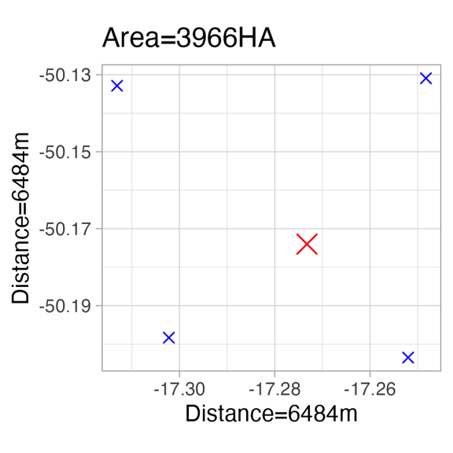

We have the same data set in two different flavours:

- hourly rain sums, just as they are measured
- hourly rain sums, on a 7 hour moving average

We have the moving averaged sums because in that way, we can correct for small differences in recodring time, which would distort the errors if analysed on an individual data point basis.

Now let’s start with our analysis. let’s sum up the rain values for individual measures for the period of January through February 2020:

|  | Rain Sum: 2019-12-31 to 2020-02-29 |
| --- | --- |
| Verification_01205953 | 576.2 |
| Station.1_00203F6D | 1983.8 |
| Station.2_0120593F | 582.4 |
| Station.3_01204052 | 522.2 |
| Station.4_01204042 | 566.6 |

|  | Rain Sum: 2019-12-31 to 2020-02-29 |
| --- | --- |
| Verification_01205953 | 578.0 |
| Station.1_00203F6D | 2090.4 |
| Station.2_0120593F | 584.4 |
| Station.3_01204052 | 535.7 |
| Station.4_01204042 | 570.5 |

Wow. Quite some differences. Now we want to know if we have a true difference between the points. That is, we want to understand if the differences arrises due to chance or if there is a systematic Difference. It is quite obvious that in the case of Station.1_00203F6D, there is a large difference (in fact, it is so large that we doubt the measurement). But the test between the other 4 stations seems to be quite interesting.

Before we go ahead, we will get some describtive Stats:

|  | Verification_01205953 | Station.1_00203F6D | Station.2_0120593F | Station.3_01204052 | Station.4_01204042 |
| --- | --- | --- | --- | --- | --- |
| Sum | 576.2000 | 1983.800 | 582.4000 | 522.2000 | 566.6000 |
| Mean | 0.4015 | 1.382 | 0.4059 | 0.3639 | 0.3948 |
| Variance | 5.7807 | 68.091 | 6.4937 | 3.8618 | 7.4017 |

We need to note here that for Rain Data, we expect the different location to have a spatial and temporal autocorrelation. This means that the individual sample points are not independent, which is an important assumption of parametric hypothesis testing. Nevertheless, many meteorological researches found that simple tests like the T-Test do not perform wors than special spatial tests. Therefore, we run through a series of different Hypothesis tests to evaluate our main hypothesis.

Here we go with the Setup:

- Variable: X = Precipitaiton Sum over a defined period of time
- We ignore the Station.1_00203F6D because we don’t trust the measurements
- Research Hypothesis: We claim that there are different microclimates inside the area
- Null Hypothesis: Hypothesize that there is no difference
- HA: X1≠X2≠X3≠X4
- H0: X1=X2=X3=X4

We start with a Two-Sample T-Test testing the largest against the smallest on the data set with the individual measures, Station.3_01204052 vs Station.2_0120593F. We have the following Test Statistic:

$$T
=\frac{(\bar{X_2}-\bar{X_1})}{s_{p}*\sqrt(\frac{1}{n_{1}}+\frac{1}{n_{2}})}$$
Where:

$$s_{p}^{2}
=\frac{(n_{1}-1)s_{1}^{2}+(n_{2}-1)s_{2}^{2}}{n_{1}+n_{2}-2}$$
And this is T-Distributed with degrees of Freedom:
$$T \sim t(df=n_{1}+n_{2}-2)$$
The Confidence Interval is calculated as follows:
$$CI = \delta X\pm t*SE_{1,2}=\delta X\pm t*
\sqrt(\frac{s_{p}}{n_{1}}+\frac{s_{p}}{n_{2}})$$

Here we go:

```r
#getting all the Parameters on board
data_1<-df1$Station.3_01204052[st:en]
data_2<-df1$Station.2_0120593F[st:en]

mean_1<-mean(data_1)
mean_2<-mean(data_2)

var_1<-var(data_1)
var_2<-var(data_2)

n_1<-length(data_1)
n_2<-length(data_2)

#Test Definition: 2-Tail Test and Level of Significance 0,05
test_tails<-2 #leans that we test whether it's larger OR smaller
sign_lev<-0.05

#calculating pooled Variance + Standard deviation
var_p<-((n_1-1)*var_1+(n_2-1)*var_2)/(n_1+n_2-2)
SD_p<-sqrt(var_p)

#Calculate Test Statistic T
Test_Stat<-(mean_1-mean_2)/(SD_p*sqrt((1/n_1)+(1/n_2)))
df<-n_1+n_2-2

#Comparing against critical Value
P_critical<-1-(sign_lev/test_tails)
critical_value <- qt(P_critical, df, lower.tail = TRUE)
P_data<-pt(abs(Test_Stat), df, lower.tail = TRUE)
p_value<-(1-P_data)*test_tails

decision<- ifelse(p_value<sign_lev,"Null Hypotesis Rejected","Null Hypothesis Not Rejected")

#confidence interval estimation
treat_eff <- mean_1-mean_2
St_error<-sqrt((var_p/n_1)+(var_p/n_2))
z_value<-qt(sign_lev/test_tails,df, lower.tail = F)
ci_low<-treat_eff-z_value*St_error
ci_up<-treat_eff+z_value*St_error
```

|  | Result T-Test | Critical Level/Data 1 | Data/Data 2 |
| --- | --- | --- | --- |
| a | Sample Means | 0.3639 | 0.4059 |
| b | Score on T-Axis | 1.9608 | -0.4938 |
| c | Probability | 0.975 | 0.6893 |
| d | α/p Value (2-Tail Prob) | 0.05 | 0.6215 |
| e | Decision | Null Hypothesis Not Rejected | 0.05 significance level |
| f | 0.95 Confidence Interval | -0.2085 | 0.1246 |

```
##
##  Two Sample t-test
##
## data:  data_1 and data_2
## t = -0.49, df = 2868, p-value = 0.6
## alternative hypothesis: true difference in means is not equal to 0
## 95 percent confidence interval:
##  -0.2085  0.1246
## sample estimates:
## mean of x mean of y
##    0.3639    0.4059
```

So this is a very clear case. The differences we observe from one mean to the other might arrise purely by chance. We cannot claim that there is a difference in microclimates. However, we ignored something important. Rainfall on such a small area is not independent. If it rains on one place, it is very likely to rain on the other place as well. this violates a basic assumption of parametric statistical tests, i.e. that the samples are independent from each other. It is not so easy to get a fix for this, but we start with a workaround. Anyway, we are not too much interested in the total rain sum over 2 months, but more in the invidiual rain fall events. That is, if one field received 300mm rain at one day per month, whereas the other obtains an equal rainfall over several days, this is a very important information, which the above test doesn’t capture. so what we do next is to perform a Paired Two-Sample T-Test. This test assumes that the samples are very much dependent, so that they always appear in pairs. This test is typicalls used in medical treatments to test before-after differences. but there is no problem in using this test also here, considering each hour a ‘pair’ with one sample being station A, the other being staiton B. We measure the overall difference.

$$w_{i} =x_{i}-y_{i}$$

Where:

$$s_{w}^{2}
=\sum_{i+1}^{n}{}\frac{(w_{i}-\bar{w_i})^{2}}{n-1}$$

And this is T-Distributed with degrees of Freedom:
$$T \sim t(df=n-1)$$

Here we go:

```r
#DOING THE PAIRED SAMPLE T TEST INVIVIDUALLY
#getting all the Parameters on board
data_1<-df1$Station.3_01204052[st:en]
data_2<-df1$Station.2_0120593F[st:en]

delta_vec<-data_1-data_2
mean_delta<-mean(delta_vec)
H_0 <- 0 #note: we test agains the Hypothesis that the diff is zero

var_w<-var(delta_vec)
SD_w<-sqrt(var_w)
n<-length(delta_vec)

#Test Definition: 2-Tail for dependent sample data and Level of Significance 0,05
test_tails<-2 #leans that we test whether it's larger OR smaller
sign_lev<-0.05


#Calculate Test Statistic T
Test_Stat<-(mean_delta-H_0)/(SD_w/sqrt(n))
df<-n-1

#Comparing against critical Value
P_critical<-1-(sign_lev/test_tails)
critical_value <- qt(P_critical, df, lower.tail = TRUE)
P_data<-pt(abs(Test_Stat), df, lower.tail = TRUE)
p_value<-(1-P_data)*test_tails

decision<- ifelse(p_value<sign_lev,"Null Hypotesis Rejected","Null Hypothesis Not Rejected")

#confidence interval estimation
treat_eff <- mean_delta
St_error<-sqrt(var_w/n)
z_value<-qt(sign_lev/test_tails,df, lower.tail = F)
ci_low<-treat_eff-z_value*St_error
ci_up<-treat_eff+z_value*St_error
```

|  | Result T-Test | Critical Level/Data 1 | Data/Data 2 |
| --- | --- | --- | --- |
| a | Mean Difference | 0 | -0.042 |
| b | Score on T-Axis | 1.9616 | -0.561 |
| c | Probability | 0.975 | 0.7125 |
| d | α/p Value (2-Tail Prob) | 0.05 | 0.5749 |
| e | Decision | Null Hypothesis Not Rejected | 0.05 significance level |
| f | 0.95 Confidence Interval | -0.1886 | 0.1047 |